Contribution of antenatal care to the improvement of maternal health NHANAG SAMUEL 2025-07-01

# INTRODUCTION

## 1. Background

According to the World Health Organization (WHO) (1), the leading complications responsible for nearly 75% of maternal deaths include:

- Severe hemorrhage (primarily postpartum);
- Infections (typically occurring after childbirth);
- Hypertensive disorders during pregnancy (such as preeclampsia and eclampsia);
- Complications during labor and delivery;
- Unsafe abortion.

According to the World Health Organization (WHO), one of the key interventions to address the leading causes of maternal mortality is the monitoring of pregnant women through a continuum of care throughout pregnancy—namely, antenatal care (ANC). WHO recommends that women attend at least eight ANC contacts during pregnancy, with the first occurring before the 16th week of gestation.

This naturally raises the question: what is the impact of these interventions on pregnancy outcomes? Does the specific context of Cameroon support the existence of this relationship—and if so, with what degree of intensity?

## 2. Objectives

The main objective is to assess the contribution of antenatal care to the reduction of maternal mortality. Specifically, the study aims to:

1. Analyze of the structure of the population of pregnant women;
2. Analyze the demand antenatal care services;
3. Analyse of antenatal care disparities

# TOOLS AND METHODOLOGY

## 1. Tools

The tools to be used for the implementation of this study include Microsoft Office Suite. The R software will be employed for data processing and analysis, including descriptive, associative, and comparative analyses, among others.

## 2. Methodology

This article will use data from the 2018 Cameroon Demographic and Health Survey (DHS 2018). The primary objective of this survey was to collect and analyze data on reproductive health, maternal, newborn, child and adolescent health, as well as family well-being. The target population for this study consists of women of reproductive age (15–49 years) who use maternal health services—specifically, women who had at least one live birth in the five years preceding the survey.

The indicators calculated as part of this work will be slightly different from those in a similar study because the data has not been extrapolated.

A descriptive analysis made it possible to understand how women of reproductive age are distributed according to their geographical location, the level of household well-being to which they belong, their level of education, and finally, their religious affiliation. A descriptive analysis also helped identify the determinants of the use of prenatal consultation services.

Finally, it should be noted that the results obtained in this study have not been extrapolated to the total population.

# RESULTS

## 1. Description of basic demographics

The objective of this section is to assess the structure of the population of women of reproductive age. This presentation is organized into three main areas: first, the age structure by region; then, the structure of women of reproductive age according to household well-being; followed by the structure based on level of education; and finally, the structure by religious affiliation.

- **Structure of age and region**

Graph 1 shows the distribution of women of reproductive age according to age and region of origin. The average age of surveyed women of reproductive age is approximately 28. This average age is generally consistent across the twelve survey regions, although some regional disparities are observed

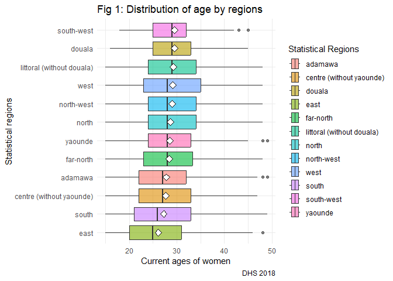

The South-West region has the lowest age dispersion among women of reproductive age, while the South and West regions exhibit the highest levels of age dispersion within this population group.

- **Structure of wealth and region**

Graph 2 shows the distribution of women of working age by region and according to the well-being of the households to which they belong. The cities of Yaoundé and Douala have a relatively low proportion of poor women compared to other surveyed regions. In contrast, the regions of Adamawa, East, Far North, and North have a higher concentration of women from very poor and poor households. These regions are also considered priority zones for Reproductive, Maternal, Newborn, Child and Adolescent Health, including Nutrition (RMNCAH+N).

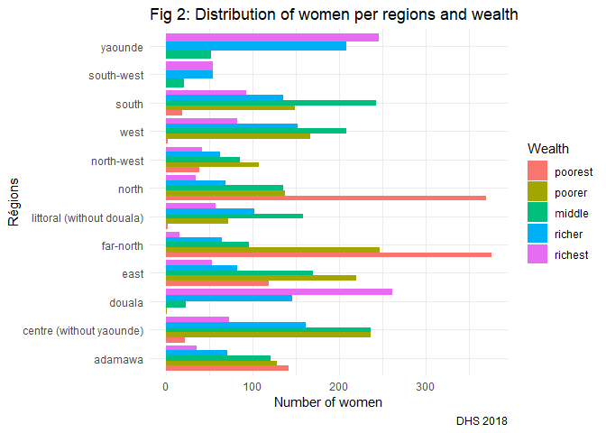

The cities of Yaounde and Douala each constitute a distinct survey region due to their unique administrative, political, and economic structures.

- **Structure of Education and region**

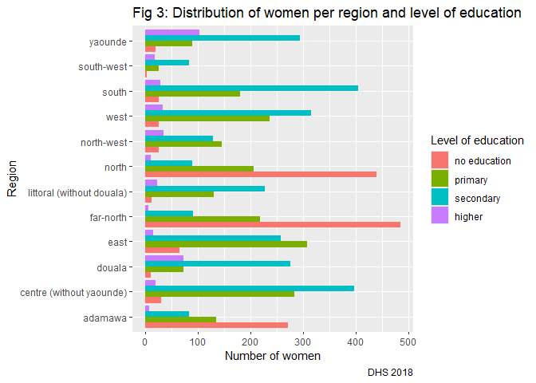

The other regions have a more or less balanced distribution of women of reproductive age with primary and secondary levels of education.

- Structure of religion and region

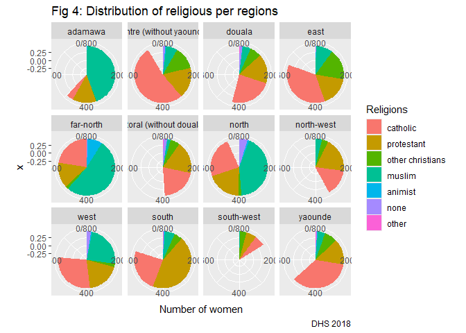

## 2. Analysis of antenatal care

- Normal antenatal care

|  | ANCno Quantity1 | ANCno Percentage1 | ANCyes Quantity2 | ANCyes Percentage2 |
| --- | --- | --- | --- | --- |
| Place of residence |  |  |  |  |
| Urban | 162 | 21.25 | 2832 | 50.81 |
| Rural | 600 | 78.74 | 2741 | 49.18 |
| Highest education level |  |  |  |  |
| No education | 488 | 56.61 | 925 | 16.59 |
| Primary | 282 | 32.71 | 1772 | 31.79 |
| Secondary | 89 | 10.32 | 2519 | 45.20 |
| Higher | 3 | 0.34 | 357 | 6.40 |

The structure of the surveyed women is presented in the table. Nearly 78% of women of childbearing age who did not attend antenatal consultations (ANC) reside in rural areas, compared to about 21% in urban areas. Likewise, more than half (56.61%) of women who did not attend ANC have no formal education, while those who did are predominantly literate. However, the low representation of literate women in the data is due to their limited number within the sample.

- Number of antenatal care by educational level

Graph 5 analyses the number of antenatal care (ANC) visits based on the level of education. It shows that the higher the level of education, the more likely women are to attend ANC visits.

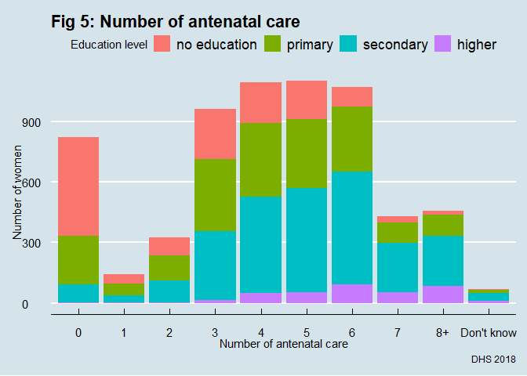

- Antenatal care within the third month of the pregnancy

An important indicator in SRMNEA+N is attending the first antenatal care (ANC) visit within the first three months of pregnancy. Graph 6 shows that, just like overall ANC attendance, early ANC visits also increase with the level of education.

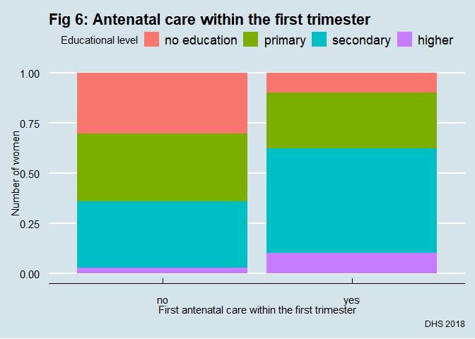

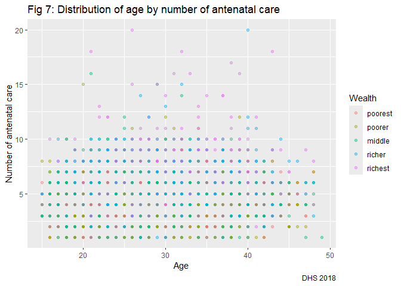

Graph 7 shows that there is no formal link between a woman’s age and the number of antenatal care (ANC) visits.

## 3. Analysis of antenatal care disparities

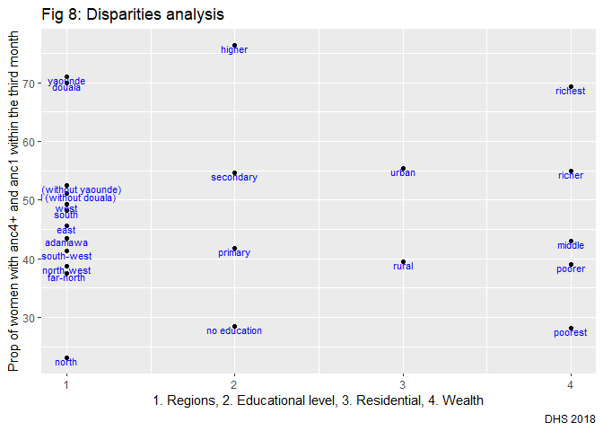

# DISCUSSION

The disparity analysis implemented has revealed a range of realities, both geographically and individually. This situation is not surprising, as it confirms findings from previous studies on the subject. Earlier Cameroon Household Surveys have shown that the poorest regions in Cameroon are Adamawa, East, Far North, and North. Given the current crisis, the Northwest and Southwest regions are also beginning to face significant problems, resulting in the deterioration of SRMNEA+N (Reproductive, Maternal, Newborn, Child, and Adolescent Health and Nutrition) indicators.

Several initiatives have been taken to designate these areas as SRMNEA priority regions in Cameroon. Although the results are slow to emerge, efforts are ongoing.

For the other disaggregation variables, it’s easy to understand that a woman who is not sufficiently educated cannot sustainable support herself. She tends to depend entirely on her partner, who may not always have a high level of education. Additionally, when accounting for factors related to religion and customs, it becomes clear why pregnant women with less education are less likely to use reproductive health services than those with a higher level of education.

Well-being and place of residence also play important roles in the use of prenatal consultation (ANC) services. An analysis of the health system shows that health services are more adequate in urban areas than in rural ones. Thus, it is understandable why service utilization is lower in rural areas. Even when a woman is willing to go to a hospital, access to services is not always guaranteed. Moreover, healthcare services come at a cost. One needs financial resources to access a health facility for consultation.

To address these barriers, several programs—such as the “Health Voucher” initiative—have been implemented. The aim of this project was to improve demand for reproductive health services by offering vouchers to women at very affordable prices.

# CONCLUSION

The analysis carried out in this study provided an opportunity to revisit the use of antenatal care (ANC) services and the disparities associated with their utilization. For this purpose, data from the 2018 Demographic and Health Survey (DHS) were used. The analysis focused on women of childbearing age who had a live birth within the five years preceding the survey.

The results revealed that disparities exist in the utilization of ANC services.

These findings should prompt the Government to take action and support the implementation of innovative strategies to address and reduce these disparities.